# Mis Primeros Fractales

# Conjuntos de Julia

Ahora podemos observar un ejemplo que trabajamos en clase

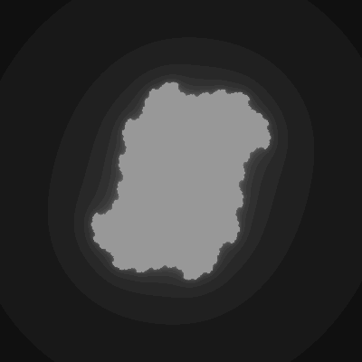

```python
#JULIA ejemplo en clase
def f(z):
    return z**2+complex(0.2,0.3)

for y in range (imgy):
    zy=y*(yb-ya)/(imgy-1)+ya
    for x in range (imgx):
        zx=x*(xb-xa)/(imgx-1)+xa
        z=complex(zx,zy)
        for i in range (maxit):
            z0=f(z)
            if abs(z)>1000:
                break
            z=z0
            r=i*8
            g=i*8
            b=i*8
            image.putpixel((x,y),(r,g,b))
image
```

Al igual que con los fractales Newton al tener un primer codigo podemos genera nuevos fractales de esta familia con el simple hecho de cambiar de función y la tonalidad de colores con la que los representamos

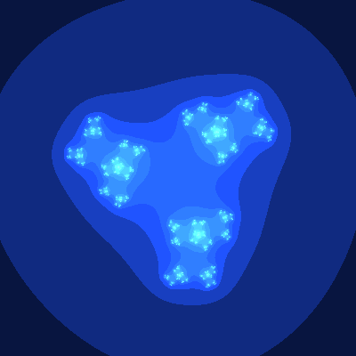

```python
#Julia 1
def f(z):
    return z**3+complex(0.5,0.8)

for y in range (imgy):
    zy=y*(yb-ya)/(imgy-1)+ya
    for x in range (imgx):
        zx=x*(xb-xa)/(imgx-1)+xa
        z=complex(zx,zy)
        for i in range (maxit):
            z0=f(z)
            if abs(z)>1000:
                break
            z=z0
            r=i*8
            g=i*21
            b=i*64
            image.putpixel((x,y),(r,g,b))
image
```

En este fractal la función que representamos fue $x^3+0.5+0.8i$

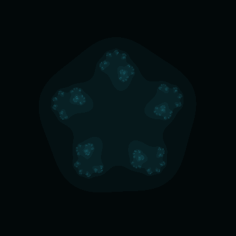

```python
#Julia 2
def f(z):
    return z**5+complex(0.2,0.9)

for y in range (imgy):
    zy=y*(yb-ya)/(imgy-1)+ya
    for x in range (imgx):
        zx=x*(xb-xa)/(imgx-1)+xa
        z=complex(zx,zy)
        for i in range (maxit):
            z0=f(z)
            if abs(z)>1000:
                break
            z=z0
            r=i*2
            g=i*8
            b=i*9
            image.putpixel((x,y),(r,g,b))
image
```

En este fractal la función que representamos fue $x^5+0.2+0.9i$

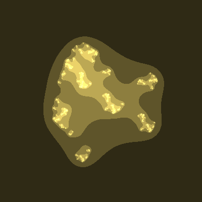

```python
#Julia 3
def f(z):
    return z**6-z**3+z+complex(0.7,0.4)

for y in range (imgy):
    zy=y*(yb-ya)/(imgy-1)+ya
    for x in range (imgx):
        zx=x*(xb-xa)/(imgx-1)+xa
        z=complex(zx,zy)
        for i in range (maxit):
            z0=f(z)
            if abs(z)>1000:
                break
            z=z0
            r=i*47
            g=i*42
            b=i*21
            image.putpixel((x,y),(r,g,b))
image
```

En este fractal la función que representamos fue $x^6-x^3+x+0.7+0.4i$

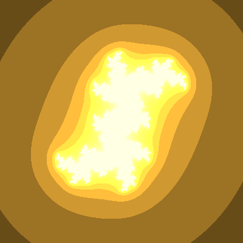

```python
#Julia 4
def f(z):
    return z**2+complex(0.25,0.56)

for y in range (imgy):
    zy=y*(yb-ya)/(imgy-1)+ya
    for x in range (imgx):
        zx=x*(xb-xa)/(imgx-1)+xa
        z=complex(zx,zy)
        for i in range (maxit):
            z0=f(z)
            if abs(z)>1000:
                break
            z=z0
            r=i*52
            g=i*38
            b=i*12
            image.putpixel((x,y),(r,g,b))
image
```

En este fractal la función que representamos fue $x^2+0.25+0.56i$

# Sistemas Iterados

Un sistema iterativo de funciones es una construcción matemática usada para representar de manera simple ciertos conjuntos fractales que presenten autosimilaridad. Muchos fractales clásicos autosimilares, autoafines y autoconformes pueden representarse como el único conjunto compacto invariante por un sistema iterativo de funciones contractivas.

Un ejemplo de sistemas iterados es el triangulo de triángulo de sierpinski, para el cual generamos el codigo en clase como se ve ahora

```
(-0.0505393573850806,
 1.0466331073850808,
 -0.05093588450848501,
 1.0470296345084849)
```

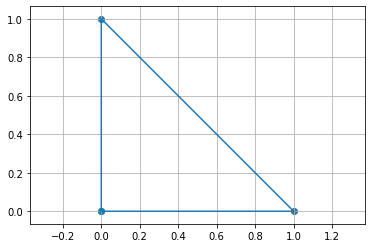

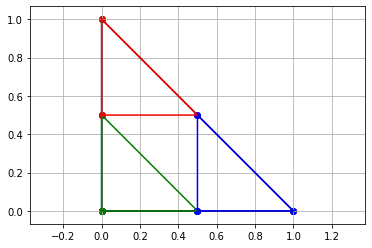

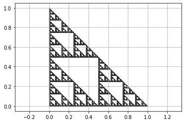

```python
#ejemplo en clase
fig=plt.figure()
ax=plt.gca()
Tri=np.array([[0,0],[1,0],[0,1],[0,0]])
plt.scatter(Tri.transpose()[0],Tri.transpose()[1])
plt.plot(Tri.transpose()[0],Tri.transpose()[1])
ax.set_xticks(np.arange(-0.2,1.4,0.2))
ax.set_yticks(np.arange(-0.2,1.4,0.2))
plt.grid()
ax.axis("equal")

def transafin(M,t,x):
    y=M@x+t
    return y

transafin([[0.5,0],[0,0.5]],[0,0],Tri[1])

fig=plt.figure()
ax=plt.gca()
Tri=np.array([[0,0],[1,0],[0,1],[0,0]])
tritrans=np.array([transafin([[0.5,0],[0,0.5]],[0,0],i) for i in Tri])
tritrans2=np.array([transafin([[0.5,0],[0,0.5]],[0,0.5],i) for i in Tri])
tritrans3=np.array([transafin([[0.5,0],[0,0.5]],[0.5,0],i) for i in Tri])
plt.scatter(Tri.transpose()[0],Tri.transpose()[1],color='black')
plt.plot(Tri.transpose()[0],Tri.transpose()[1],color='black')
plt.scatter(tritrans.transpose()[0],tritrans.transpose()[1],color='g')
plt.plot(tritrans.transpose()[0],tritrans.transpose()[1],color='g')
plt.scatter(tritrans2.transpose()[0],tritrans2.transpose()[1],color='r')
plt.plot(tritrans2.transpose()[0],tritrans2.transpose()[1],color='r')
plt.scatter(tritrans3.transpose()[0],tritrans3.transpose()[1],color='b')
plt.plot(tritrans3.transpose()[0],tritrans3.transpose()[1],color='b')
ax.set_xticks(np.arange(-0.2,1.4,0.2))
ax.set_yticks(np.arange(-0.2,1.4,0.2))
plt.grid()
ax.axis("equal")


Tri=np.concatenate((tritrans,tritrans2,tritrans3))
Tri

fig=plt.figure()
ax=plt.gca()
Tri=np.array([[0,0]])
for i in range(8):
    tritrans=np.array([transafin([[0.5,0],[0,0.5]],[0,0],i) for i in Tri])
    tritrans2=np.array([transafin([[0.5,0],[0,0.5]],[0,0.5],i) for i in Tri])
    tritrans3=np.array([transafin([[0.5,0],[0,0.5]],[0.5,0],i) for i in Tri])
    Tri=np.concatenate((tritrans,tritrans2,tritrans3))
plt.scatter(Tri.transpose()[0],Tri.transpose()[1],color='black',s=0.2)
ax.set_xticks(np.arange(-0.2,1.4,0.2))
ax.set_yticks(np.arange(-0.2,1.4,0.2))
plt.grid()
ax.axis("equal")
```

# Conjuntos de Mandelbrot

Ahora observemos un ejemplo que trabajamos en clase

[figure not shown]

```python
# Mandelbrot ejemplo en clase
def f(z,a,b):
    return z**2+complex(a,b)

for y in range (imgy):
    zy=y*(yb-ya)/(imgy-1)+ya
    for x in range (imgx):
        zx=x*(xb-xa)/(imgx-1)+xa
        z=0
        for i in range (maxit):
            z0=f(z,zx ,zy )
            if abs(z)>1000:
                break
            z=z0
            r=i*8
            g=i*8
            b=i*8
            image.putpixel((x,y),(r,g,b))
image
```

```python
def Mandelbrot(Ejemplo):
    if Ejemplo=='1':
        try:
          def f(z,a,b):
              return z**2+2*z**3+1+complex(a,b)

          for y in range (imgy):
              zy=y*(yb-ya)/(imgy-1)+ya
              for x in range (imgx):
                  zx=x*(xb-xa)/(imgx-1)+xa
                  z=0
                  for i in range (maxit):
                      z0=f(z,zx ,zy )
                      if abs(z)>1000:
                          break
                      z=z0
                      r=i*25
                      g=i*10
                      b=i*45
                      image.putpixel((x,y),(r,g,b))
          return image
        except:
            pass
    if Ejemplo=='2':
        try:
          def f(z,a,b):
              return z**7-z**3+complex(a,b)

          for y in range (imgy):
              zy=y*(yb-ya)/(imgy-1)+ya
              for x in range (imgx):
                  zx=x*(xb-xa)/(imgx-1)+xa
                  z=0
                  for i in range (maxit):
                      z0=f(z,zx ,zy )
                      if abs(z)>1000:
                          break
                      z=z0
                      r=i*8
                      g=i*14
                      b=i*26
                      image.putpixel((x,y),(r,g,b))
          return image

        except:
            pass
    if Ejemplo=='3':
        try:
          def f(z,a,b):
              return z**3+z**2+z+complex(a,b)

          for y in range (imgy):
              zy=y*(yb-ya)/(imgy-1)+ya
              for x in range (imgx):
                  zx=x*(xb-xa)/(imgx-1)+xa
                  z=0
                  for i in range (maxit):
                      z0=f(z,zx ,zy )
                      if abs(z)>1000:
                          break
                      z=z0
                      r=i*10
                      g=i*40
                      b=i*25
                      image.putpixel((x,y),(r,g,b))
          return image
        except:
            pass
    if Ejemplo=='4':
        try:
          def f(z,a,b):
              return z**5-complex(a,b)

          for y in range (imgy):
              zy=y*(yb-ya)/(imgy-1)+ya
              for x in range (imgx):
                  zx=x*(xb-xa)/(imgx-1)+xa
                  z=0
                  for i in range (maxit):
                      z0=f(z,zx ,zy )
                      if abs(z)>1000:
                          break
                      z=z0
                      r=i*45
                      g=i*25
                      b=i*25
                      image.putpixel((x,y),(r,g,b))
          return image

        except:
            pass
interact(Mandelbrot, Ejemplo = ['1','2','3', '4'])
```

```
<function __main__.Mandelbrot(Ejemplo)>
```

Para el desarrollo y comprension de estos fractales fuera de la explicacion obtenida en clase, se tuvieron referencias de: -https://es.qwe.wiki/wiki/Newton_fractal#:~:text=Fractal%20de%20Newton%20%2D%20Newton%20fractal&text=Un%20conjunto%20abierto%20para%20el,conjunto%20Fatou%20para%20la%20iteraci%C3%B3n.&text=Por%20lo%20tanto%20cada%20punto,de%20los%20conjuntos%20de%20Fatou. -https://es.wikipedia.org/wiki/Sistema_iterativo_de_funciones